# Ocean Acidification

Document Author

2023-04-08

Main Question: Can we quantify ocean acidification in the subtropical north Atlantic Ocean? 1) Is the surface ocean pCO2 increasing? 2) Is the surface ocean pH decreasing? 3) Is the surface ocean seawater saturation state with respect to aragonite decreasing?

Assigment Format Intro > Methods > Results > Discussion mini-lab report

### Load required libraries

```r
library(tidyverse)
library(seacarb)
library(performance)
```

###Import Data from BATS

```r
bats_bottle <- read_delim("bats_bottle.txt", delim = "\t", escape_double = FALSE,
                          col_names = FALSE, trim_ws = TRUE, skip = 60)
View(bats_bottle)

colnames(bats_bottle) <- colnames(read_csv("bats_bottle.txt", skip = 59))
#Check that I have done this correctly!
View(bats_bottle)
#I have a data frame of BATS data with column names for variables
```

Variable Units -yyyymmdd = Year Month Day  
decy = Decimal Year  
time = Time (hhmm)  
latN = Latitude (Deg N) lonW = Longitude (Deg W) Depth = Depth (m)  
Temp = Temperature ITS-90 (C)  
CTD_S = CTD Salinity (PSS-78)  
Sal1 = Salinity-1 (PSS-78)  
Sig-th = Sigma-Theta (kg/m^3)  
O2(1) = Oxygen-1 (umol/kg)  
OxFixT = Oxygen Fix Temp (C)  
Anom1 = Oxy Anomaly-1 (umol/kg)  
CO2 = dissolved inorganic carbon (umol/kg)  
Alk = Alkalinity (uequiv)  
NO31 = Nitrate+Nitrite-1 (umol/kg) NO21 = Nitrite-1 (umol/kg)  
PO41 = Phosphate-1 (umol/kg)  
Si1 = Silicate-1 (umol/kg)  
POC = POC (ug/kg)  
PON = PON (ug/kg)  
TOC = TOC (umol/kg)  
TN = TN (umol/kg)  
Bact = Bacteria enumeration (cells*10^8/kg)  
POP = POP (umol/kg) TDP = Total dissolved Phosphorus (nmol/kg) SRP = Low-level phosphorus (nmol/kg) BSi = Particulate biogenic silica (umol/kg) LSi = Particulate lithogenic silica (umol/kg) Pro = Prochlorococcus (cells/ml) Syn = Synechococcus (cells/ml) Piceu = Picoeukaryotes (cells/ml) Naneu = Nanoeukaryotes (cells/ml)

### Calculate CO2 chemistry parameters

```r
?carb(seacarb)
```

```
## starting httpd help server ... done
```

```r
#carb(flag, var1, var2, S=35, T=25, Patm=1, P=0, Pt=0, Sit=0,
        #k1k2="x", kf="x", ks="d", pHscale="T", b="u74", gas="potential",
        #warn="y", eos="eos80", long=1.e20, lat=1.e20)
#We have TA, DIC, S, T, Pt, Sit, but we don't have pressure.

#First we need to calculate pressure (dbar) using TEOS-10:
?gsw
#p= gsw_p_from_z(z,lat)
bats_co2=bats_bottle %>%
  mutate(P_dbar=gsw_p_from_z(Depth*-1,latN))
View(bats_co2)

#We now have all of the variables that we neeed to calculate the surface seawater chemistry at the BATS station, but we need to be very careful about our units!

#We now have TA, DIC, S, Pt, Sit, and Pressure
#What are  the units of these what does CO2SYS need?
#Ta is in uequiv (umol/kg) and we need mol/kg
#S is in PSS and we will use EOS80
#T is in degrees C and we need degrees C
#Pt is in umol/kg and we need mol/kg
#SIT is in umol/kg and we need mol/kg
#P_dbar is in dbar and we need bar

#We will need to convert units scaling when using CO2SYS

#flag = 15 ALK and DIC given
?carb
bats_co2sys=
  bats_co2 %>%
  filter(Alk!=-999,CO2!=-999,Sal1!=-999,Temp!=-999,
         P_dbar!=-999,PO41!=-999,Si1!=-999,
         lonW!=-999,latN!=-999)%>%
  rename(DIC=CO2) %>%
  mutate(carb(flag=15, var1=Alk*10^-6, var2=DIC*10^-6,
              S=Sal1, T=Temp, Patm=1, P=P_dbar*10^-1,
              Pt=PO41*10^-6, Sit=Si1*10^-6,
              k1k2="l", kf="pf", ks="d", pHscale="T",
              b="u74", gas="potential",
              warn="y", eos="eos80",long=360-lonW, lat=latN))
```

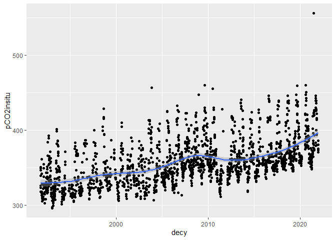

```r
#filter for only the surface ocean
bats_co2sys_surf = bats_co2sys %>%
  filter(Depth<100) %>% #we are selecting only the upper 100m
  filter(pCO2insitu>100) #BATS told me this data point is bad.

#1) Is surface ocean pCO2 increasing?

bats_co2sys_surf %>%
  ggplot(mapping=aes(x=decy,y=pCO2insitu))+
  geom_point()+
  geom_smooth()
```

```r
check=bats_co2sys_surf %>%
  filter(pCO2<200)

pco2_model = lm(pCO2insitu~decy,data=bats_co2sys_surf)
summary(pco2_model)
```

```
##
## Call:
## lm(formula = pCO2insitu ~ decy, data = bats_co2sys_surf)
##
## Residuals:
##     Min      1Q  Median      3Q     Max
## -52.302 -18.081  -7.098  12.657 173.045
##
## Coefficients:
##               Estimate Std. Error t value Pr(>|t|)
## (Intercept) -3.396e+03  1.328e+02  -25.57   <2e-16 ***
## decy         1.869e+00  6.616e-02   28.25   <2e-16 ***
## ---
## Signif. codes:  0 '***' 0.001 '**' 0.01 '*' 0.05 '.' 0.1 ' ' 1
##
## Residual standard error: 25.75 on 1937 degrees of freedom
## Multiple R-squared:  0.2919, Adjusted R-squared:  0.2915
## F-statistic: 798.3 on 1 and 1937 DF,  p-value: < 2.2e-16
```

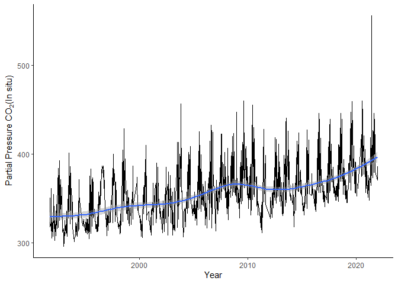

```r
#For Homework:
#Make decy vs PCO2 plot pretty

bats_co2sys_surf %>%
  ggplot(mapping=aes(x=decy,y=pCO2insitu))+
  geom_line()+
  geom_smooth()+
  scale_y_continuous()+
  scale_x_continuous()+
  xlab(expression(paste("Year")))+
  ylab(expression(paste("Partial Pressure CO"[2], "(In situ)")))+
  theme_classic()
```

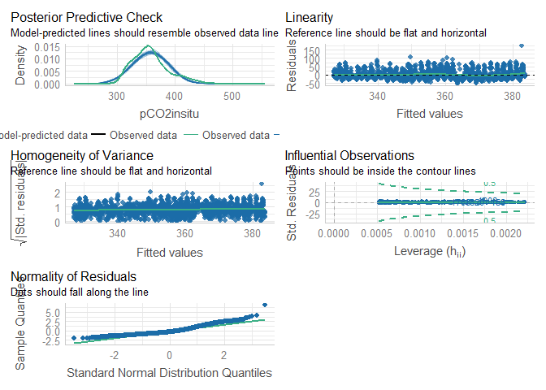

```r
#Could include methods text for CO2SYS in lab report

#For Thursday:
#How do we check our model performance?
#How do we plot our model predictions?

#2) IS surface ocean seawater pH decreasing?
#3) Is surface ocean seawater saturation state with respect to aragonite decreasing?
#These two questions for thursday

################################################################################################
#How do we check our model performance?

#Checking model performance
#install.packages("performance")
library(performance)
library(see)
check_model(pco2_model)
```

```r
summary(pco2_model)
```

```
##
## Call:
## lm(formula = pCO2insitu ~ decy, data = bats_co2sys_surf)
##
## Residuals:
##     Min      1Q  Median      3Q     Max
## -52.302 -18.081  -7.098  12.657 173.045
##
## Coefficients:
##               Estimate Std. Error t value Pr(>|t|)
## (Intercept) -3.396e+03  1.328e+02  -25.57   <2e-16 ***
## decy         1.869e+00  6.616e-02   28.25   <2e-16 ***
## ---
## Signif. codes:  0 '***' 0.001 '**' 0.01 '*' 0.05 '.' 0.1 ' ' 1
##
## Residual standard error: 25.75 on 1937 degrees of freedom
## Multiple R-squared:  0.2919, Adjusted R-squared:  0.2915
## F-statistic: 798.3 on 1 and 1937 DF,  p-value: < 2.2e-16
```

```r
anova(pco2_model) #p-value is the same as summary
```

```
## Analysis of Variance Table
##
## Response: pCO2insitu
##             Df  Sum Sq Mean Sq F value    Pr(>F)
## decy         1  529187  529187  798.33 < 2.2e-16 ***
## Residuals 1937 1283970     663
## ---
## Signif. codes:  0 '***' 0.001 '**' 0.01 '*' 0.05 '.' 0.1 ' ' 1
```

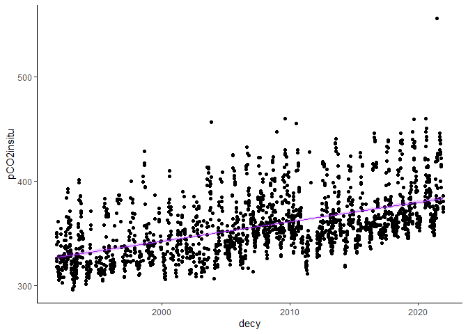

```r
#How do plot our model prediction?

#The tidy way is with diplyr

bats_co2sys_surf_pred=
bats_co2sys_surf %>%
  mutate(predict(pco2_model,interval='confidence', level=0.95))
#the base r way with cbind an do not need to rename outputs

bats_co2sys_surf_pred=
  cbind(bats_co2sys_surf, predict(pco2_model, interval='confidence', level=0.95))

#predict(pco2_model,as.data.frame(decy=seq(1990,2020,0.1)), interval='confidence',level=0.95)

bats_co2sys_surf_pred %>%
  ggplot()+
  geom_point(mapping=aes(x=decy,y=pCO2insitu))+
  geom_line(aes(decy,fit),color="purple")+
  geom_ribbon(aes(x=decy,ymin=lwr,ymax=upr),alpha=0.2,fill="purple")+
  theme_classic()
```